# ADA Homework 2

Samantha Rabinowitz, sar4357

3/3/2020

## Challenge 1

The R code below will load the ‘movies.csv’ dataset from GitHub and organize the data into a tibble.

```r
f <- "https://raw.githubusercontent.com/difiore/ADA-datasets/master/IMDB-movies.csv"
d <- read_csv(f, col_names = T)
glimpse(d)
```

```
## Observations: 28,938
## Variables: 10
## $ tconst         <chr> "tt0002130", "tt0002844", "tt0003037", "tt0003165", "t…
## $ titleType      <chr> "movie", "movie", "movie", "movie", "movie", "movie", …
## $ primaryTitle   <chr> "Dante's Inferno", "Fantômas: In the Shadow of the Gui…
## $ startYear      <dbl> 1911, 1913, 1913, 1913, 1913, 1914, 1914, 1914, 1914, …
## $ runtimeMinutes <dbl> 68, 54, 61, 90, 85, 78, 148, 59, 61, 82, 195, 59, 72, …
## $ genres         <chr> "Adventure,Drama,Fantasy", "Crime,Drama", "Crime,Drama…
## $ averageRating  <dbl> 7.0, 7.0, 7.0, 7.0, 6.5, 6.5, 7.1, 6.9, 6.2, 6.3, 6.4,…
## $ numVotes       <dbl> 2082, 1877, 1307, 1010, 1686, 1068, 2907, 1126, 1207, …
## $ nconst         <chr> "nm0078205", "nm0275421", "nm0275421", "nm0275421", "n…
## $ director       <chr> "Francesco Bertolini", "Louis Feuillade", "Louis Feuil…
```

The following code will filter the dataset to just include movies from 1920 to 1979 and movies that are less than 4 hours long. Columns were also added to make **startYear** a new variable called **decade**.

```r
d1 <- d %>%
  filter(startYear >= "1920" & startYear <="1979" & runtimeMinutes < 240) %>%
  mutate(decade = case_when(startYear >=1920 & startYear<=1929 ~ "20s",
                            startYear >=1930 & startYear<=1939 ~ "30s",
                            startYear >=1940 & startYear<=1949 ~ "40s",
                            startYear >=1950 & startYear<=1959 ~ "50s",
                            startYear >=1960 & startYear<=1969 ~ "60s",
                            startYear >=1970 & startYear<=1979 ~ "70s"))
d1 %>% glimpse()
```

```
## Observations: 5,741
## Variables: 11
## $ tconst         <chr> "tt0010323", "tt0011000", "tt0011130", "tt0011237", "t…
## $ titleType      <chr> "movie", "movie", "movie", "movie", "movie", "movie", …
## $ primaryTitle   <chr> "The Cabinet of Dr. Caligari", "Leaves From Satan's Bo…
## $ startYear      <dbl> 1920, 1920, 1920, 1920, 1920, 1920, 1920, 1920, 1920, …
## $ runtimeMinutes <dbl> 76, 167, 82, 76, 73, 107, 90, 77, 145, 90, 79, 75, 117…
## $ genres         <chr> "Fantasy,Horror,Mystery", "Drama", "Drama,Horror,Sci-F…
## $ averageRating  <dbl> 8.1, 6.7, 7.0, 7.2, 6.7, 7.1, 7.4, 6.2, 7.4, 6.7, 6.3,…
## $ numVotes       <dbl> 52649, 1047, 4561, 6128, 1063, 2053, 1927, 1356, 4799,…
## $ nconst         <chr> "nm0927468", "nm0003433", "nm0731910", "nm0091380", "n…
## $ director       <chr> "Robert Wiene", "Carl Theodor Dreyer", "John S. Robert…
## $ decade         <chr> "20s", "20s", "20s", "20s", "20s", "20s", "20s", "20s"…
```

The code below utilizes *ggplot* to plot histograms of the distribution of **runtimeMinutes** for each decade.

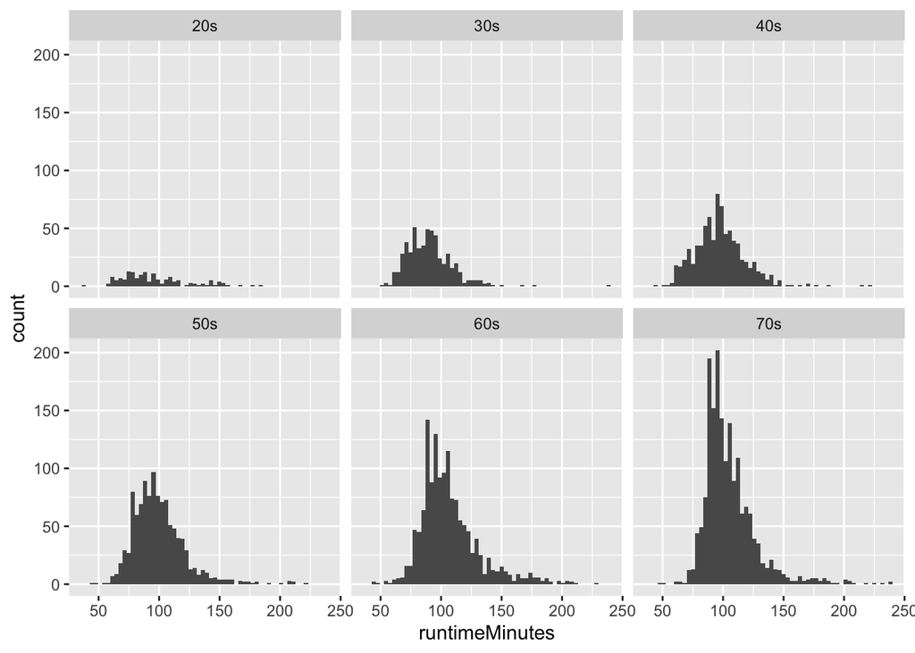

```r
d1 %>%
  ggplot(aes(x=runtimeMinutes)) + geom_histogram(bins=60) + facet_wrap(~ decade)
```

The R code below will compute the population mean and population standard deviation in **runtimeMinutes** for each decade and store the values in a new dataframe, *results*.

```r
results <- d1 %>% group_by(decade) %>% summarize(mean=mean(runtimeMinutes),
                                      pop_sd=sdpop(runtimeMinutes))
results %>% glimpse()
```

```
## Observations: 6
## Variables: 3
## $ decade <chr> "20s", "30s", "40s", "50s", "60s", "70s"
## $ mean   <dbl> 95.95513, 90.24254, 97.30341, 99.64168, 106.82781, 105.06640
## $ pop_sd <dbl> 27.43508, 18.64468, 20.55356, 21.54956, 24.30888, 21.35976
```

The following code will generate a function to calculate the standard error of the mean for each decade as well as a single sample of 100 movies from each decade and calculate the sample mean and standard deviation for each decade. Additionally, the SE around each population mean for each decade will be estimated using the standard deviation and sample size of these samples.

```r
std_error <- function(x) {
  sd(x) / sqrt(length(x))
}
d1 %>% group_by(decade) %>% sample_n(100, replace=FALSE) %>%
  summarize(mean(runtimeMinutes), sd(runtimeMinutes),std_error(runtimeMinutes))
```

```
## # A tibble: 6 x 4
##   decade `mean(runtimeMinutes)` `sd(runtimeMinutes)` `std_error(runtimeMinutes)`
##   <chr>                   <dbl>                <dbl>                       <dbl>
## 1 20s                      94.3                 28.0                        2.80
## 2 30s                      90.4                 23.0                        2.30
## 3 40s                      99.7                 22.3                        2.23
## 4 50s                     101.                  25.2                        2.52
## 5 60s                     106.                  22.3                        2.23
## 6 70s                     106.                  22.2                        2.22
```

The code below will write a function to calculate the standard error of the mean for each deacde using the population standard deviation for purposes of comparison to the values obtained from the sample created above.

```r
pop_std_error <- function(x) {
  sdpop(x) / (sqrt(100))
}
d1 %>% group_by(decade) %>%
  summarize(mean = mean(runtimeMinutes),
            sdpop = sdpop(runtimeMinutes),
            pop_se = pop_std_error(runtimeMinutes))
```

```
## # A tibble: 6 x 4
##   decade  mean sdpop pop_se
##   <chr>  <dbl> <dbl>  <dbl>
## 1 20s     96.0  27.4   2.74
## 2 30s     90.2  18.6   1.86
## 3 40s     97.3  20.6   2.06
## 4 50s     99.6  21.5   2.15
## 5 60s    107.   24.3   2.43
## 6 70s    105.   21.4   2.14
```

The following will generate a sampling distribution of mean **runtimeMinutes** for each decade by (a) drawing 10,000 samples of 100 movies from each decade and, for each sample, (b) calculating the mean **runtimeMinutes** and the standard deviation in **runtimeMinutes**.

```r
k <- 10000
n <- 100
s <- list()
t <- list()
  for (i in unique(d1$decade)) {
    d2 <- filter(d1, decade==i)
    s[[i]] <- do(k) * mean(~runtimeMinutes, data = sample_n(d2, size = n, replace = FALSE))
    t[[i]] <- do(k) * sd(~runtimeMinutes, data = sample_n(d2, size = n, replace = FALSE))
  }
head(s[[1]])
```

```
##    mean
## 1 95.13
## 2 96.44
## 3 95.70
## 4 93.83
## 5 98.11
## 6 94.69
```

```r
head(t[[1]])
```

```
##         sd
## 1 27.45276
## 2 28.24312
## 3 25.79800
## 4 28.44843
## 5 28.37224
## 6 26.89872
```

## Challenge 2

```r
ppois(13, lambda = 18)
```

```
## [1] 0.1425978
```

```r
dpois(0, lambda = 18)
```

```
## [1] 1.522998e-08
```

```r
dpois(7, lambda = 18)
```

```
## [1] 0.00185002
```

```r
1-ppois(20, lambda = 18)
```

```
## [1] 0.2692798
```

The below code will plot a Poisson mass function with a lambda value of 18 over an x range of 0 to 40.

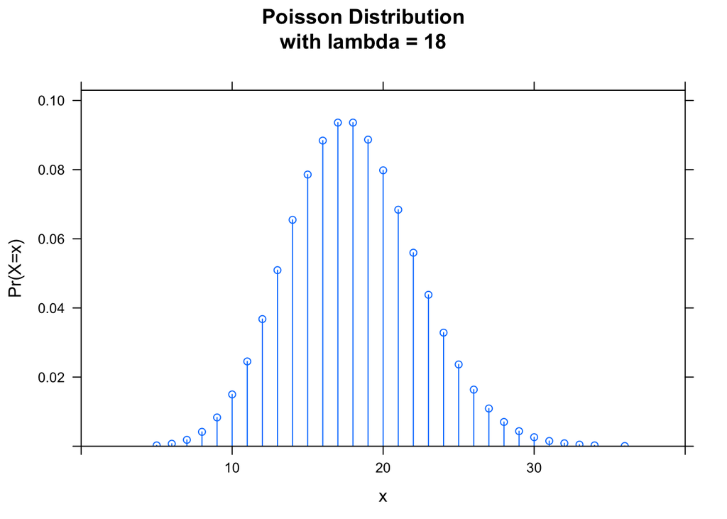

```r
plotDist("pois", lambda = 18, main = "Poisson Distribution\nwith lambda = 18", xlab = "x", xlim = c(0:40), ylab = "Pr(X=x)")
```

The following R code will simulate 520 (10 years of Saturday call omnitoring sessions) results from the above distribution. Following creation of these results, a histogram will be plotted to compare to the shape of the above probability mass function.

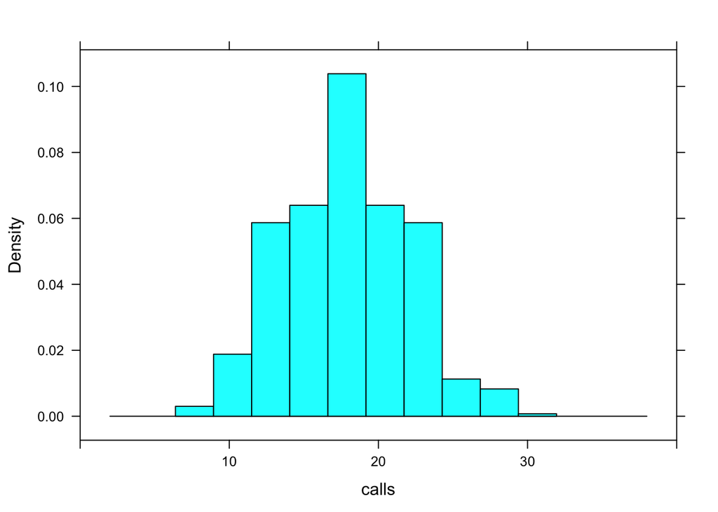

```r
calls <- rpois(520, lambda = 18)
histogram(calls, xlim=c(0:40))
```

The general shape of the histogram of simulated results above reflects what is seen in the Poisson probability mass function. If the simulation included a greater number of results, this histogram may more closely match what is shown in the probability ass function plot.

## Challenge 3

The R code below will load the ‘zombies.csv’ dataset from GitHub and organize the data into a tibble.

```r
f <- "https://raw.githubusercontent.com/difiore/ADA-datasets/master/zombies.csv"
d <- read_csv(f, col_names = T)
glimpse(d)
```

```
## Observations: 1,000
## Variables: 10
## $ id                 <dbl> 1, 2, 3, 4, 5, 6, 7, 8, 9, 10, 11, 12, 13, 14, 15,…
## $ first_name         <chr> "Sarah", "Mark", "Brandon", "Roger", "Tammy", "Ant…
## $ last_name          <chr> "Little", "Duncan", "Perez", "Coleman", "Powell", …
## $ gender             <chr> "Female", "Male", "Male", "Male", "Female", "Male"…
## $ height             <dbl> 62.88951, 67.80277, 72.12908, 66.78484, 64.71832, …
## $ weight             <dbl> 132.0872, 146.3753, 152.9370, 129.7418, 132.4265, …
## $ zombies_killed     <dbl> 2, 5, 1, 5, 4, 1, 0, 4, 9, 2, 4, 4, 2, 5, 4, 2, 5,…
## $ years_of_education <dbl> 1, 3, 1, 6, 3, 4, 4, 0, 3, 3, 4, 3, 1, 5, 5, 2, 1,…
## $ major              <chr> "medicine/nursing", "criminal justice administrati…
## $ age                <dbl> 17.64275, 22.58951, 21.91276, 18.19058, 21.10399, …
```

The code below will calculate the population mean and standard deviation for each quantitative random variable.

```r
d %>% summarize(height_mean=mean(height),
                weight_mean=mean(weight),
                age_mean=mean(age),
                n_zombies_mean=mean(zombies_killed),
                ed_mean=mean(years_of_education))
```

```
## # A tibble: 1 x 5
##   height_mean weight_mean age_mean n_zombies_mean ed_mean
##         <dbl>       <dbl>    <dbl>          <dbl>   <dbl>
## 1        67.6        144.     20.0           2.99    3.00
```

```r
d %>% summarize(height_sd=sdpop(height),
                weight_sd=sdpop(weight),
                age_sd=sdpop(age),
                n_zombies_sd=sdpop(zombies_killed),
                ed_sd=sdpop(years_of_education))
```

```
## # A tibble: 1 x 5
##   height_sd weight_sd age_sd n_zombies_sd ed_sd
##       <dbl>     <dbl>  <dbl>        <dbl> <dbl>
## 1      4.31      18.4   2.96         1.75  1.68
```

The following will utilize *ggplot2* to make scatterplots of height and weight in relation to age.

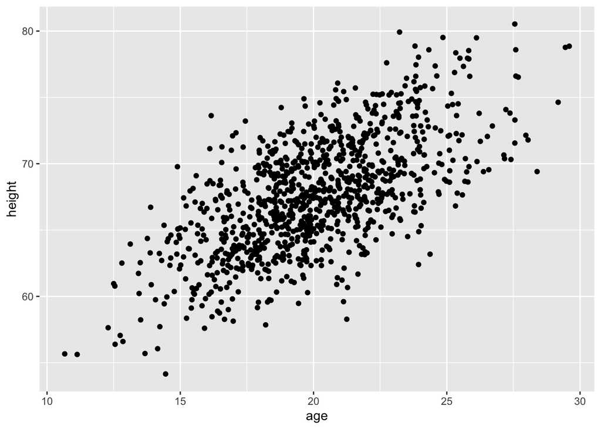

```r
d %>% ggplot(aes(x=age,y=height)) + geom_point()
```

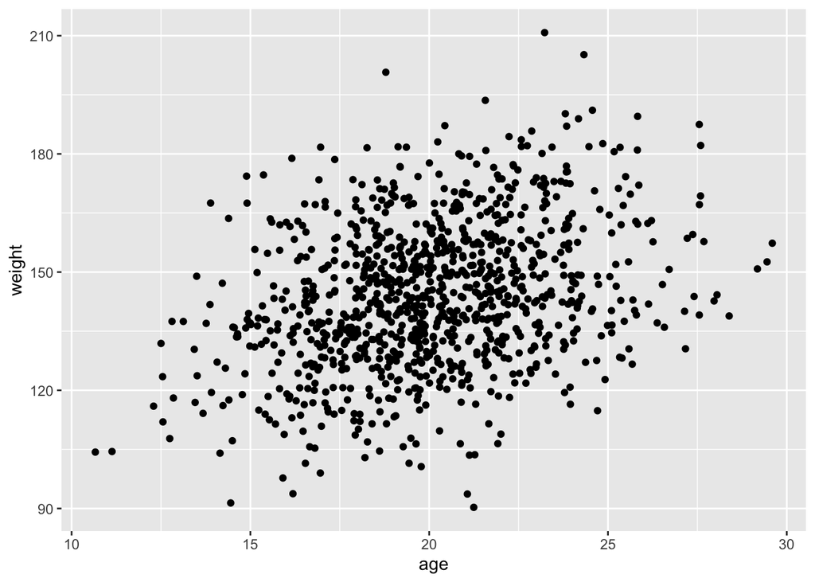

```r
d %>% ggplot(aes(x=age,y=weight)) + geom_point()
```

The scatterplot generated for height in relation to age shows a distinct positive relationship. The scatterplot generated for weight in relation to age does not show as strong of a relationship however there is still a positive tendency to the relationship between the two variables.

The following code will generate histograms and Q-Q plots for the numeric variables in the dataset to test for normality of the data.

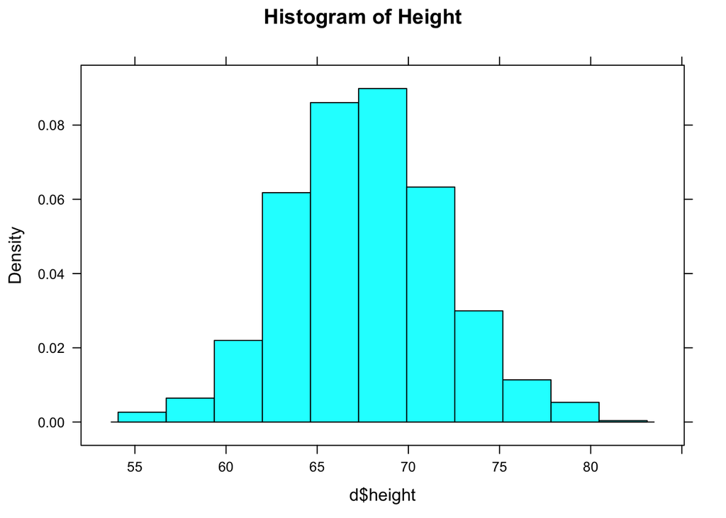

```r
histogram(d$height, main= "Histogram of Height")
```

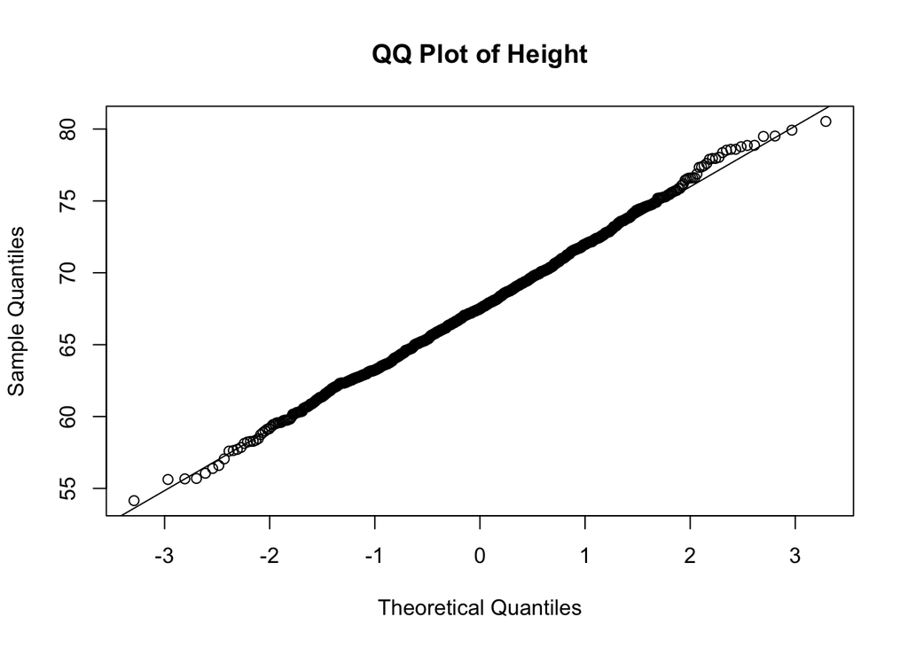

```r
qqnorm(d$height, main="QQ Plot of Height")
qqline(d$height)
```

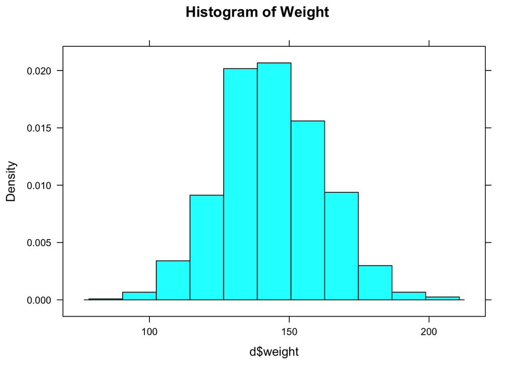

```r
histogram(d$weight, main= "Histogram of Weight")
```

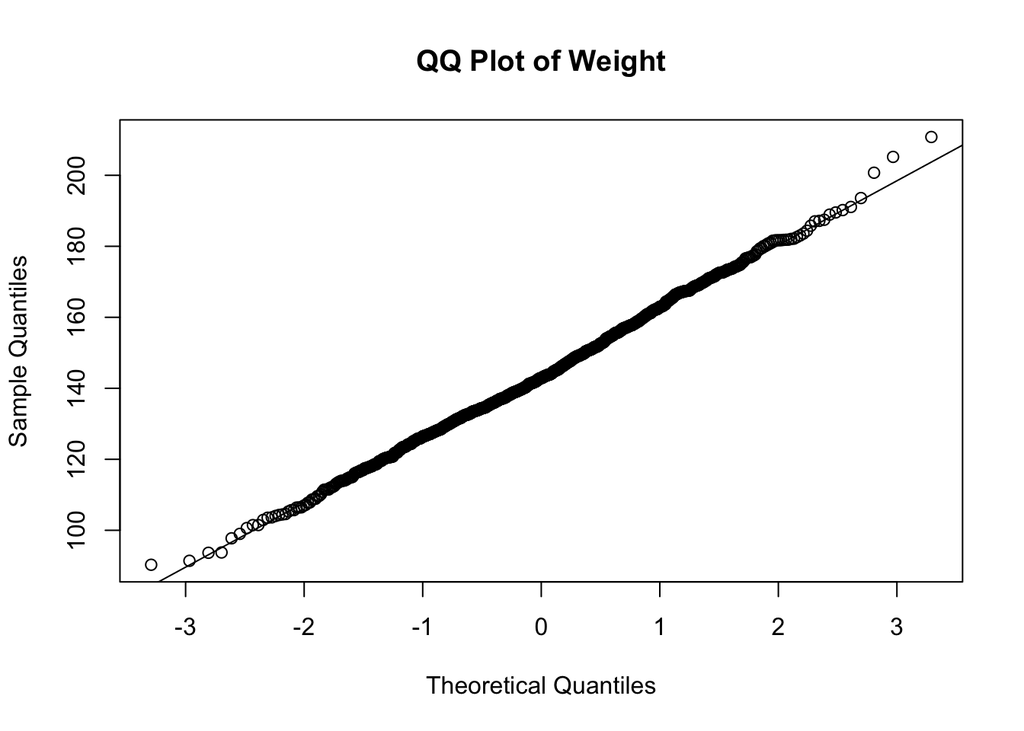

```r
qqnorm(d$weight, main="QQ Plot of Weight")
qqline(d$weight)
```

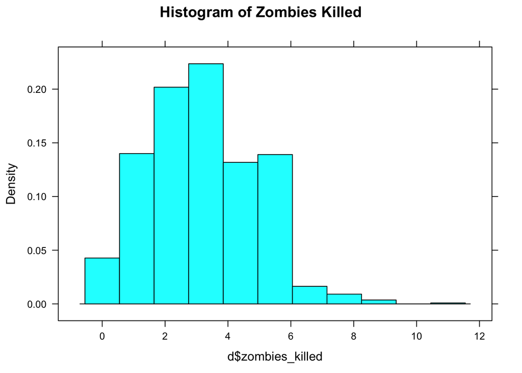

```r
histogram(d$zombies_killed, main= "Histogram of Zombies Killed")
```

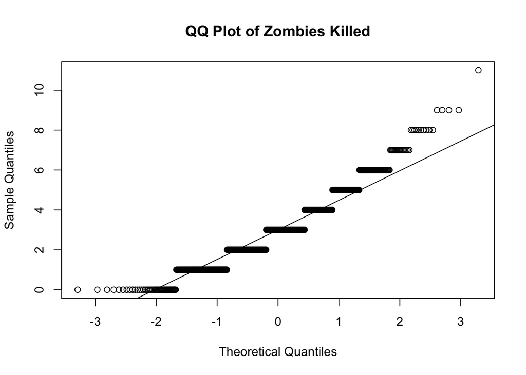

```r
qqnorm(d$zombies_killed, main="QQ Plot of Zombies Killed")
qqline(d$zombies_killed)
```

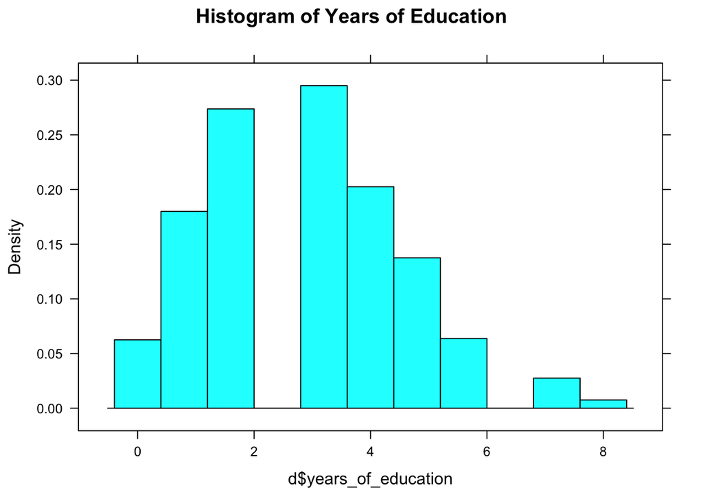

```r
histogram(d$years_of_education, main= "Histogram of Years of Education")
```

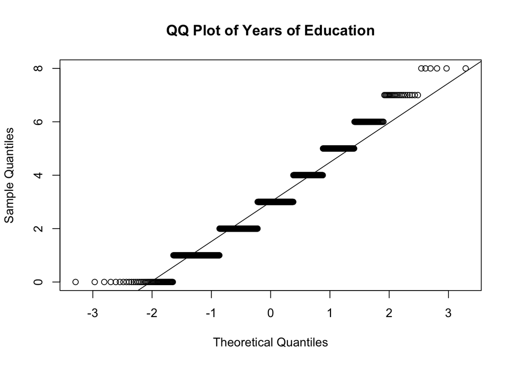

```r
qqnorm(d$years_of_education, main="QQ Plot of Years of Education")
qqline(d$years_of_education)
```

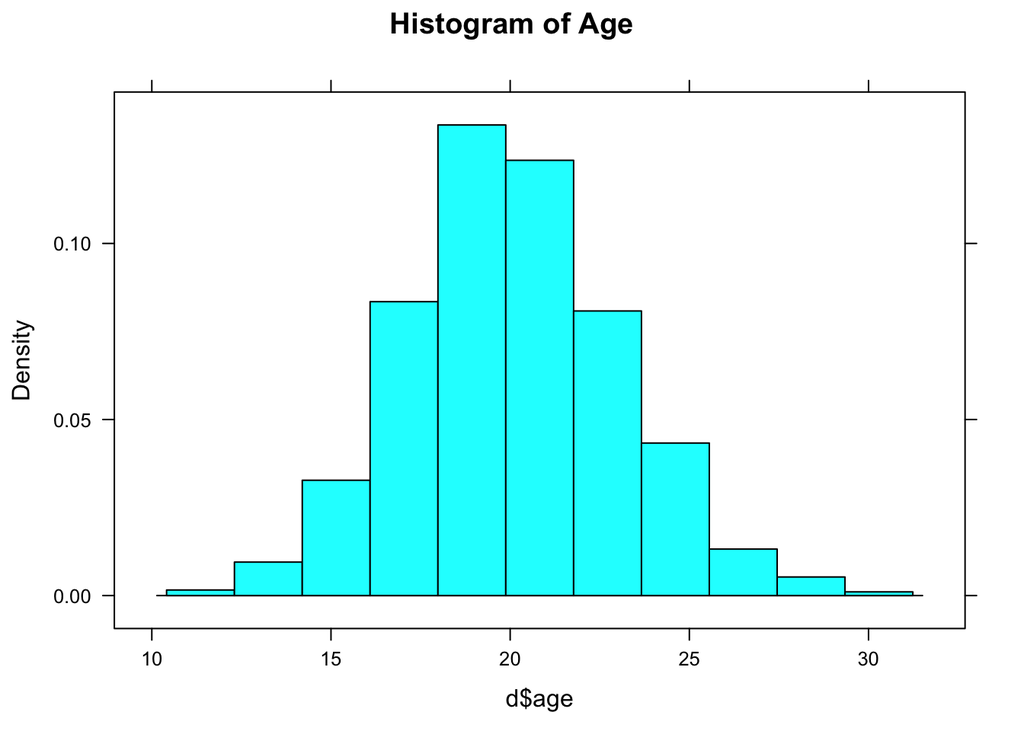

```r
histogram(d$age, main= "Histogram of Age")
```

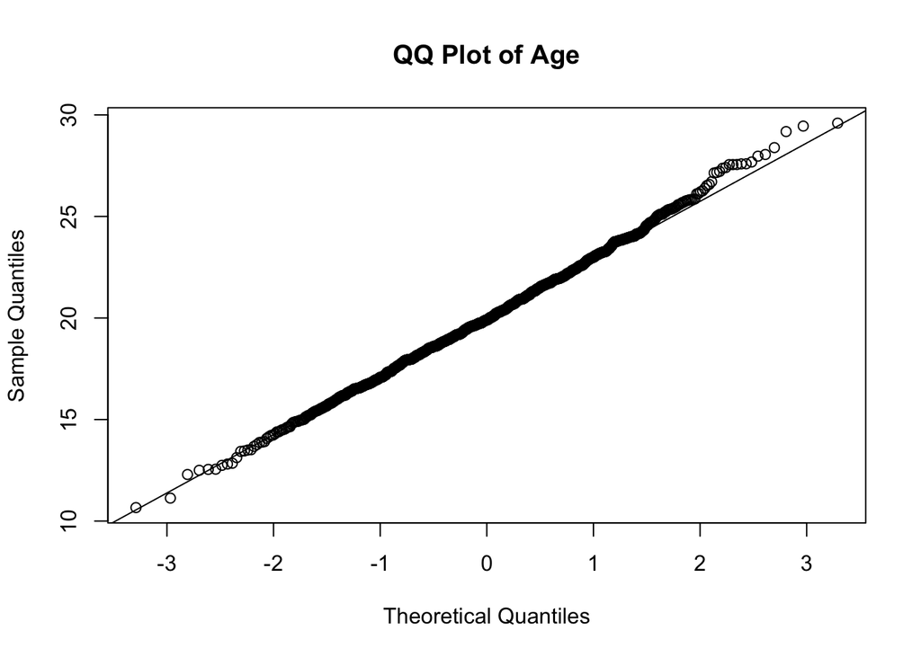

```r
qqnorm(d$age, main="QQ Plot of Age")
qqline(d$age)
```

As demonstrated by the histograms and Q-Q plots above, the height, weight, and age variables seem to be drawn from a normal distribution. The plots generated for the number of zombies killed and years of education indicate that these variables are not drawn from a normal distribution.

The R code below will sample one subset of 30 zombie apocalypse survivors from this population and calculate the mean and standard deviation for each variable. Additionally, the standard error for each variable and a 95% confidence interval will be calculated.

```r
sample1 <- d %>% sample_n(30, replace = FALSE)
sample1_stats <- sample1 %>% summarize_if(is.numeric, list(mean=mean,sd=sd, std_error=std_error))
sample1_stats %>% glimpse()
```

```
## Observations: 1
## Variables: 18
## $ id_mean                      <dbl> 476.6333
## $ height_mean                  <dbl> 68.15656
## $ weight_mean                  <dbl> 147.3537
## $ zombies_killed_mean          <dbl> 2.6
## $ years_of_education_mean      <dbl> 2.766667
## $ age_mean                     <dbl> 20.01726
## $ id_sd                        <dbl> 299.9254
## $ height_sd                    <dbl> 4.501325
## $ weight_sd                    <dbl> 19.72345
## $ zombies_killed_sd            <dbl> 1.588754
## $ years_of_education_sd        <dbl> 1.612095
## $ age_sd                       <dbl> 2.754718
## $ id_std_error                 <dbl> 54.75864
## $ height_std_error             <dbl> 0.8218258
## $ weight_std_error             <dbl> 3.600993
## $ zombies_killed_std_error     <dbl> 0.2900654
## $ years_of_education_std_error <dbl> 0.2943269
## $ age_std_error                <dbl> 0.5029404
```

```r
ci_height <- sample1_stats$height_mean + c(-1, 1) * qt(1 - 0.05 / 2, df = 30 - 1) * sample1_stats$height_std_error
ci_height
```

```
## [1] 66.47574 69.83738
```

```r
ci_weight <- sample1_stats$weight_mean + c(-1, 1) * qt(1 - 0.05 / 2, df = 30 - 1) * sample1_stats$weight_std_error
ci_weight
```

```
## [1] 139.9889 154.7186
```

```r
ci_zombies_killed <- sample1_stats$zombies_killed_mean + c(-1, 1) * qt(1 - 0.05 / 2, df = 30 - 1) * sample1_stats$zombies_killed_std_error
ci_zombies_killed
```

```
## [1] 2.00675 3.19325
```

```r
ci_years_of_education <- sample1_stats$years_of_education_mean + c(-1, 1) * qt(1 - 0.05 / 2, df = 30 - 1) * sample1_stats$years_of_education_std_error
ci_years_of_education
```

```
## [1] 2.164700 3.368633
```

```r
ci_age <- sample1_stats$age_mean + c(-1, 1) * qt(1 - 0.05 / 2, df = 30 - 1) * sample1_stats$age_std_error
ci_age
```

```
## [1] 18.98863 21.04589
```

The code below will generate an additional 99 samples and calculate the means for each of these samples. These means will make up a sampling distribution for each variable. Following generation of these samples, the means and standard deviations of each sampling distribution will be calculated. Q-Q Plots for the sampling distributions were also created to test for normality in the distributions, including those for variables determined to not be normally distributed.

```r
x <- list()
  for (i in 1:99) {
    x[[i]] <- sample_n(d, 30, replace = FALSE) %>% select(-id) %>% summarize_if(is.numeric, list(mean=mean), na.rm=T)
  }
samp_dist <- bind_rows(x)
sample1_stats <- sample1_stats %>% select(height_mean, weight_mean, zombies_killed_mean, years_of_education_mean, age_mean)
sample1_stats %>% full_join(samp_dist) %>% glimpse()
```

[output not shown]

```
## Observations: 100
## Variables: 5
## $ height_mean             <dbl> 68.15656, 67.21348, 67.93840, 68.99125, 67.36…
## $ weight_mean             <dbl> 147.3537, 144.2943, 142.9126, 149.9520, 143.5…
## $ zombies_killed_mean     <dbl> 2.600000, 3.133333, 2.933333, 2.800000, 3.200…
## $ years_of_education_mean <dbl> 2.766667, 2.833333, 2.633333, 2.266667, 2.800…
## $ age_mean                <dbl> 20.01726, 19.76774, 20.64908, 20.29602, 20.00…
```

```r
samp_dist %>% summarize_all(mean)
```

```
## # A tibble: 1 x 5
##   height_mean weight_mean zombies_killed_mean years_of_education_mean age_mean
##         <dbl>       <dbl>               <dbl>                   <dbl>    <dbl>
## 1        67.6        144.                3.00                    3.04     20.0
```

```r
samp_dist %>% summarize_all(sd)
```

```
## # A tibble: 1 x 5
##   height_mean weight_mean zombies_killed_mean years_of_education_mean age_mean
##         <dbl>       <dbl>               <dbl>                   <dbl>    <dbl>
## 1       0.752        3.36               0.318                   0.298    0.479
```

```r
pop_se <- function(x) {
 sdpop(x) / (sqrt(30))
}
sample1 %>% select(-id) %>% summarize_if(is.numeric, pop_se)
```

```
## # A tibble: 1 x 5
##   height weight zombies_killed years_of_education   age
##    <dbl>  <dbl>          <dbl>              <dbl> <dbl>
## 1  0.808   3.54          0.285              0.289 0.494
```

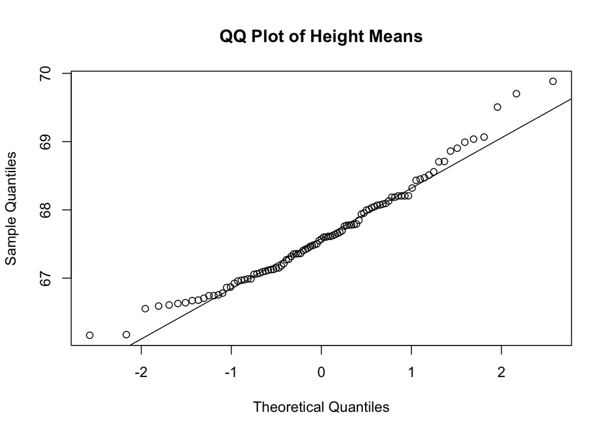

```r
qqnorm(samp_dist$height_mean, main="QQ Plot of Height Means")
qqline(samp_dist$height_mean)
```

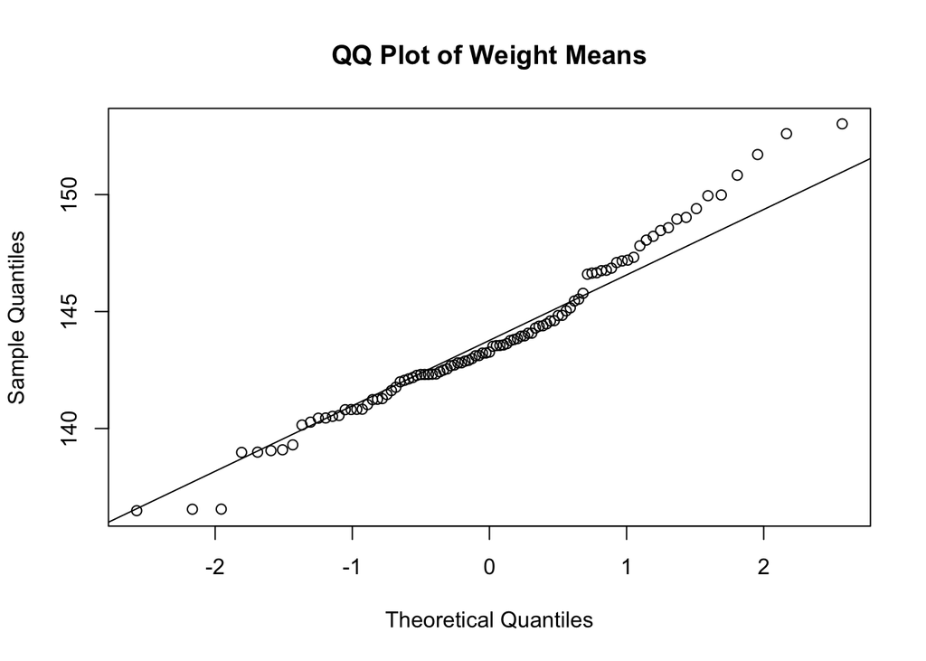

```r
qqnorm(samp_dist$weight_mean, main="QQ Plot of Weight Means")
qqline(samp_dist$weight_mean)
```

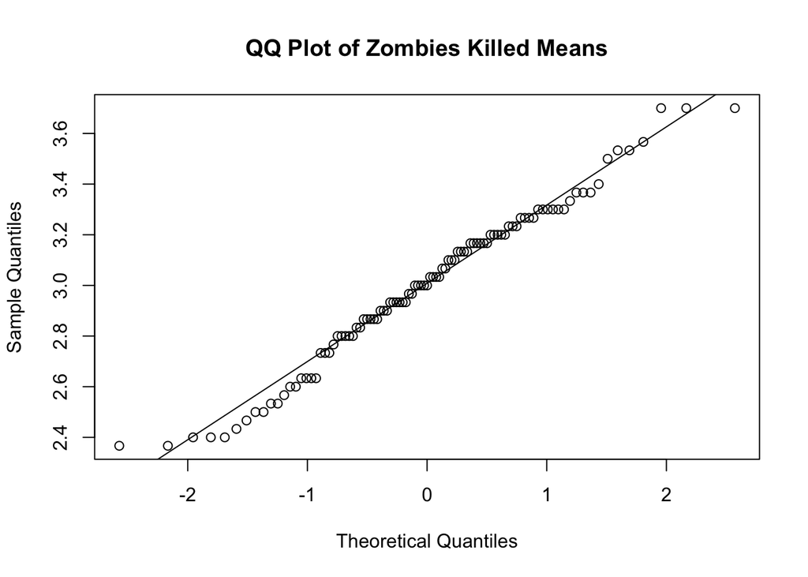

```r
qqnorm(samp_dist$zombies_killed_mean, main="QQ Plot of Zombies Killed Means")
qqline(samp_dist$zombies_killed_mean)
```

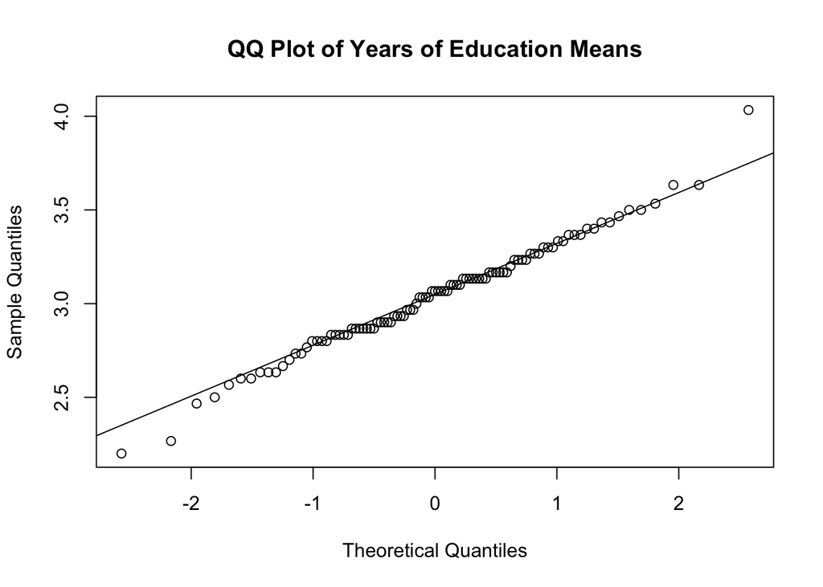

```r
qqnorm(samp_dist$years_of_education_mean, main="QQ Plot of Years of Education Means")
qqline(samp_dist$years_of_education_mean)
```

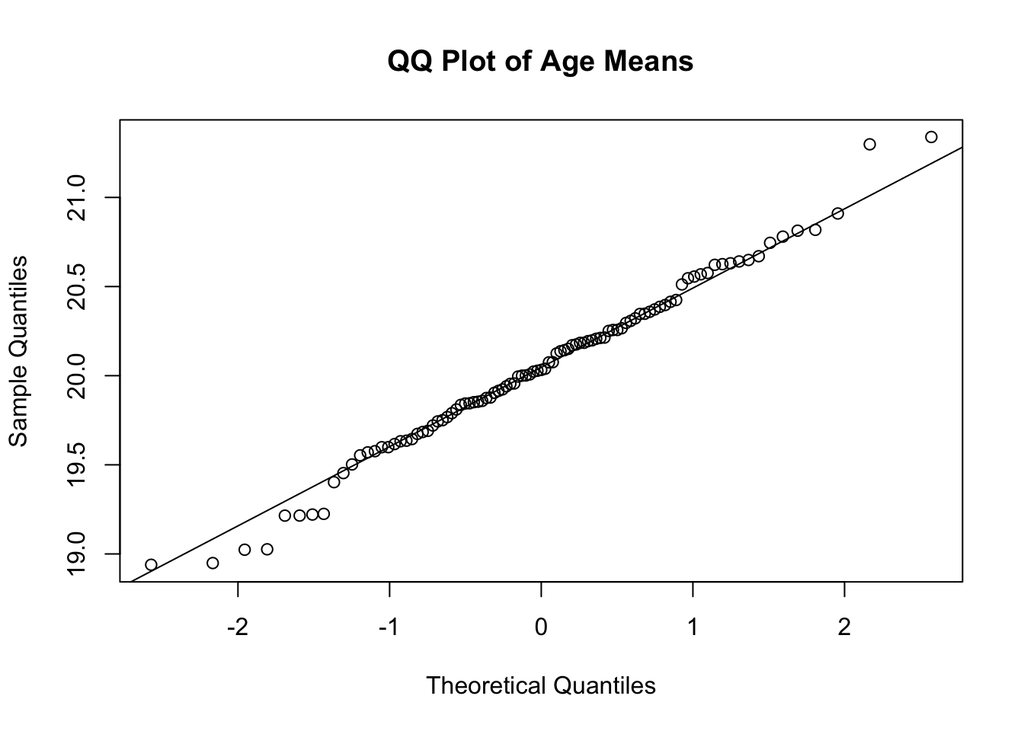

```r
qqnorm(samp_dist$age_mean, main="QQ Plot of Age Means")
qqline(samp_dist$age_mean)
```

The above Q-Q plots demonstrate that the sampling distributions for each variable follow a relatively normal distrubution. This includes the **zombies_killed** and **years_of_education** variables that were found previously to not follow a normal distrubution in the original population.